# ST2195 Programming for Data Science Extracting Data from Plain Text

## Import

The R function `scan()` can be used to read data from a file. For example, in order to read the measurements in `nile.txt` (see previous section for more details), we do

```r
nile <- scan("nile.txt")
nile
```

```
##   [1] 1120 1160  963 1210 1160 1160  813 1230 1370 1140  995  935 1110  994 1020
##  [16]  960 1180  799  958 1140 1100 1210 1150 1250 1260 1220 1030 1100  774  840
##  [31]  874  694  940  833  701  916  692 1020 1050  969  831  726  456  824  702
##  [46] 1120 1100  832  764  821  768  845  864  862  698  845  744  796 1040  759
##  [61]  781  865  845  944  984  897  822 1010  771  676  649  846  812  742  801
##  [76] 1040  860  874  848  890  744  749  838 1050  918  986  797  923  975  815
##  [91] 1020  906  901 1170  912  746  919  718  714  740
```

Note here that we assign the result of `scan("nile.txt")` to a variable called `nile`, and we assume that `nile.txt` is in our working directory (type `getwd()` to see your working directory). If `nile.txt` is not in your working directory, section “Installing and Interacting with R” describes how you can change it. Alternatively, you can replace `scan("/path/to/nile.txt")`, where `/path/to/` is the path to the directory that `nile.txt` leaves, or, if you are using the terminal, navigating into the directory where `nile.txt` is and starting R from there. In what follows, we assume that all the data files we import data from are in the working directory.

Each call to `scan()` can read a particular type of data. For example, the above line of code read the contents of `nile.txt` as `double` ([double precision numbers](https://en.wikipedia.org/wiki/Double-precision_floating-point_format))

```r
typeof(nile)
```

```
## [1] "double"
```

The `typeof()` function can be used to determine the R internal type or storage mode of any object (here of `nile`).

So, a histogram of the annual flow of the river Nile between 1871 and 1970 is

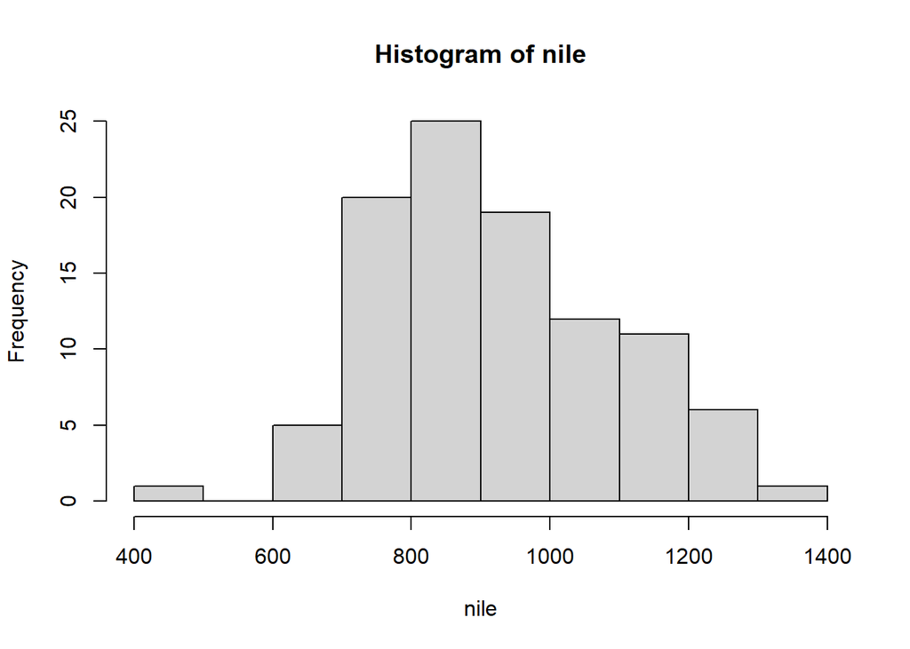

```r
hist(nile)
```

If we want to read the contents of `nile.txt` as characters we do

```r
nile_char <- scan("nile.txt", what = character())
nile_char
```

```
##   [1] "1120" "1160" "963"  "1210" "1160" "1160" "813"  "1230" "1370" "1140"
##  [11] "995"  "935"  "1110" "994"  "1020" "960"  "1180" "799"  "958"  "1140"
##  [21] "1100" "1210" "1150" "1250" "1260" "1220" "1030" "1100" "774"  "840"
##  [31] "874"  "694"  "940"  "833"  "701"  "916"  "692"  "1020" "1050" "969"
##  [41] "831"  "726"  "456"  "824"  "702"  "1120" "1100" "832"  "764"  "821"
##  [51] "768"  "845"  "864"  "862"  "698"  "845"  "744"  "796"  "1040" "759"
##  [61] "781"  "865"  "845"  "944"  "984"  "897"  "822"  "1010" "771"  "676"
##  [71] "649"  "846"  "812"  "742"  "801"  "1040" "860"  "874"  "848"  "890"
##  [81] "744"  "749"  "838"  "1050" "918"  "986"  "797"  "923"  "975"  "815"
##  [91] "1020" "906"  "901"  "1170" "912"  "746"  "919"  "718"  "714"  "740"
```

```r
typeof(nile_char)
```

```
## [1] "character"
```

By default, `scan()` expects to read “white-space” delimited files. For reading files with different delimiters, the sep argument can be used. For example, the contents of `sunset-salvo-sem` are as follows

> The;combination;of;some;data;and;an;aching;desire;for;an;answer;does;not;ensure;that; a;reasonable;answer;can;be;extracted;from;a;given;body;of;data

Hence, the words are delimited by semi-colon (;), and we need to tell that to `scan()` in order to extract them:

```r
scan("sunset-salvo-sem.txt", what=character(), sep = ";")
```

```
##  [1] "The"         "combination" "of"          "some"        "data"
##  [6] "and"         "an"          "aching"      "desire"      "for"
## [11] "an"          "answer"      "does"        "not"         "ensure"
## [16] "that"        "a"           "reasonable"  "answer"      "can"
## [21] "be"          "extracted"   "from"        "a"           "given"
## [26] "body"        "of"          "data"
```

`scan()` is one of the most basic utilities for reading data in R. It may seem simple at first but it offers a wide range of options, including skipping lines, reading only the first few lines of a file and reading different data types in tabular data; for example, we can read the data in `running_dat.tsv` by skipping the first line with the names, specifying that the file is tab-delimited (`sep = "\t"`), and that the first column is a character and the others are numbers (note that the type of data is specified here by simply supplying a `list` of a character and a number to `what`).

```r
scan("running_dat.tsv", what=list("", 1.0, 1.0, 1.0, 1.0, 1.0, 1.0), sep="\t", skip = 1)
```

```
## [[1]]
##  [1] "2013-06-01 18:40:29" "2013-06-01 18:40:30" "2013-06-01 18:40:31"
##  [4] "2013-06-01 18:40:32" "2013-06-01 18:40:33" "2013-06-01 18:40:34"
##  [7] "2013-06-01 18:40:35" "2013-06-01 18:40:36" "2013-06-01 18:40:37"
## [10] "2013-06-01 18:40:38" "2013-06-01 18:40:39"
##
## [[2]]
##  [1] 50.81381 50.81383 50.81385 50.81387 50.81388 50.81389 50.81391 50.81393
##  [9] 50.81395 50.81395 50.81396
##
## [[3]]
##  [1] -1.712606 -1.712649 -1.712700 -1.712734 -1.712777 -1.712826 -1.712862
##  [8] -1.712911 -1.712963 -1.712994 -1.713053
##
## [[4]]
##  [1] 80.20001 80.00000 79.79999 79.79999 79.59998 79.59998 79.40002 79.40002
##  [9] 79.20001 79.20001 79.00000
##
## [[5]]
##  [1] 1805.94 1810.00 1814.55 1817.53 1820.50 1824.15 1827.38 1832.03 1836.18
## [10] 1838.18 1842.39
##
## [[6]]
##  [1] 133 133 133 133 133 133 133 133 133 133 133
##
## [[7]]
##  [1] 4.060059 4.550049 2.979981 2.969971 3.650024 3.229980 4.650024 4.149902
##  [9] 2.000000 4.210083 5.189941
```

## Export

A convenient way to write lines to a file is the function `cat()`. `cat()` is used to output objects either in the standard output connection (typically directly in the R prompt), or to a file. For example,

```r
cat(nile, file = "nile1.txt", sep = ",")
```

will create a file called `nile1.txt` in the working directory, where the values stored in `nile` are separated by `,`. See `?cat` for more information. Other useful, low-level functions to export lines whose help pages you may want to check out are `write` and `writeLines`.